# PhosR: analysis of FL83B and Hepa 1-6 insulin stimuation dataset

Di Xiao; Pengyi Yang

10 April, 2020

**Description:** This Rmarkdown file documents the imputation and downstream differential phosphorylation and signalling pathway enrichment analysis of the FL83B and Hepa 1-6 insulin stimuation dataset.

# 1 Data wrangling steps

```r
library(PhosR)
load("./phospho_NB_raw.RData")
```

Extacting mouse cell line insulin stimulation data. Select columns that correspond to phosphosite quantification of FL83B and Hepa 1-6 cells in control and insulin stimulated conditions. After selecting the raw data from these columns transform the data using log2 and mark the missing values as NA.

```r
phospho.cells.Ins <- as.matrix(log2(phospho.raw[,c(grep("FL83B_Control_\\d$", colnames(phospho.raw)),
                                                   grep("FL83B_Ins_\\d$", colnames(phospho.raw)),
                                                   grep("Hepa1.6_Control_\\d$", colnames(phospho.raw)),
                                                   grep("Hepa1.6_Ins_\\d$", colnames(phospho.raw)))]))
phospho.cells.Ins[is.infinite(phospho.cells.Ins)] <- NA
```

Extract the grouping information for biological replicates in each cell type and condition.

```r
grps <- gsub("_\\d", "", colnames(phospho.cells.Ins))
```

# 2 Filtering of phosphosites

Select sites that have at least 50% quantification rate (q > 0.5) in one or more conditions

```r
phospho.cells.Ins.filtered <- selectGrps(phospho.cells.Ins, grps, 0.5, n=1)
dim(phospho.cells.Ins)
```

```
## [1] 49617    24
```

```r
dim(phospho.cells.Ins.filtered)
```

```
## [1] 17630    24
```

# 3 Imputation

## 3.1 Site- and condition-specific imputation

For each phosphosite in each condition, impute its missing values in that condition (if any) using site- and condition-specific imputation (scImpute) if the quantification rate in that condition is equal or greater than 50%.

```r
set.seed(123)
cols <- rep(c("#ED4024", "#7FBF42", "#3F61AD", "#9B822F"), each=6)
phospho.cells.Ins.impute1 <- scImpute(phospho.cells.Ins.filtered, 0.5, grps)[,colnames(phospho.cells.Ins.filtered)]
```

## 3.2 Paired tail-based imputation

For each phosphosite, impute missing values with an estimated background value if we have 4 or more biological replicates quantified in insulin stimulated condition and 0 replicates quantified in the control condition.

```r
phospho.cells.Ins.impute <- phospho.cells.Ins.impute1
# Impute data for FL83B in control using tail imputation approach
phospho.cells.Ins.impute[,1:6] <- ptImpute(phospho.cells.Ins.impute1[,7:12],
                                           phospho.cells.Ins.impute1[,1:6], 4, 0, paired = FALSE)
```

```
## [1] "idx1: 371"
```

```r
# Impute data for Hepa 1-6 in control using tail imputation aproach
phospho.cells.Ins.impute[,13:18] <- ptImpute(phospho.cells.Ins.impute1[,19:24],
                                             phospho.cells.Ins.impute1[,13:18], 4, 0, paired = FALSE)
```

```
## [1] "idx1: 632"
```

```r
# centring data across their median
phospho.cells.Ins.ms <- medianScaling(phospho.cells.Ins.impute, scale = FALSE)
```

## 3.3 Quantification plots

Barplot showing quantification rate before and after the above imputation procedure

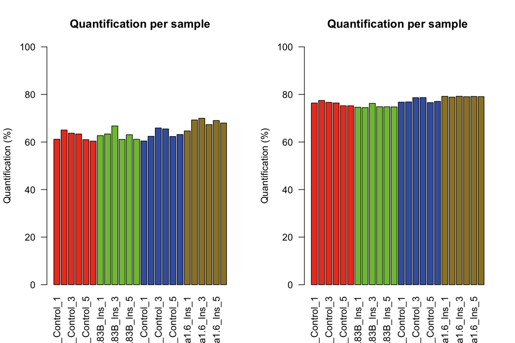

```r
par(mfrow=c(1,2))
plotQC(phospho.cells.Ins.filtered, labels=colnames(phospho.cells.Ins.filtered), panel = 1, cols = cols)
plotQC(phospho.cells.Ins.ms, labels=colnames(phospho.cells.Ins.ms), panel = 1, cols = cols)
```

Clustering of biological replicates before and after the above imputation procedure

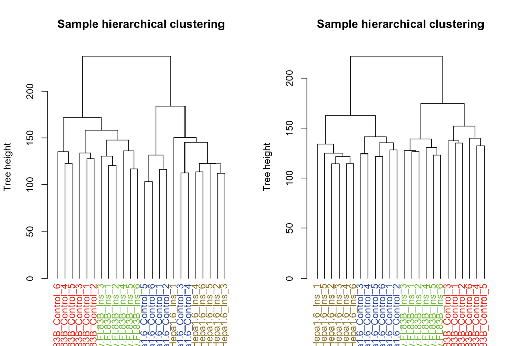

```r
par(mfrow=c(1,2))
plotQC(phospho.cells.Ins.filtered, labels=colnames(phospho.cells.Ins.filtered), panel = 2, cols = cols)
plotQC(phospho.cells.Ins.ms, labels=colnames(phospho.cells.Ins.ms), panel = 2, cols = cols)
```

# 4 Calling differentially phosphorylated sites

We use limma package for calling for differentially phosphorylated sites

```r
library(limma)
# construct design matrix by group
f <- gsub("Intensity.", "", grps)
design <- model.matrix(~ f - 1)
```

## 4.1 Analysis of data before (without) imputation

Fitting a linear model to the phosphorylation level for each phosphosite.

```r
# fit linear model for each phosphosite
fit <- lmFit(phospho.cells.Ins.filtered, design)
# construct the constrast matrix corresponding to the FL83B and Hepa 1-6 in control.
contrast.matrix <- makeContrasts(fFL83B_Ins-fFL83B_Control, fHepa1.6_Ins-fHepa1.6_Control, levels=design)
# compute contrasts from linear model fit
fit2 <- contrasts.fit(fit, contrast.matrix)
# compute empirical bayes statistics from above linear model fit
fit2 <- eBayes(fit2)
```

Counting and visualise differentially phosphorylated sites for FL83B cells in control and insulin-simulated condition before imputation.

```r
# Order the genes by how differentially they expressed
FL83B.b.DE <- topTable(fit2, coef="fFL83B_Ins - fFL83B_Control", number = Inf)
plot(FL83B.b.DE[,"logFC"], -log10(FL83B.b.DE[,"P.Value"]))

# Identify genes which are significantly upregulated
sel <- which(FL83B.b.DE[,"adj.P.Val"] < 0.05 & FL83B.b.DE[,"logFC"] > 0)
length(sel)
```

```
## [1] 307
```

```r
points(FL83B.b.DE[sel,"logFC"], -log10(FL83B.b.DE[sel,"P.Value"]), pch=16, col="red")

# Identify genes which are significantly downregulated
sel <- which(FL83B.b.DE[,"adj.P.Val"] < 0.05 & FL83B.b.DE[,"logFC"] < 0)
length(sel)
```

```
## [1] 556
```

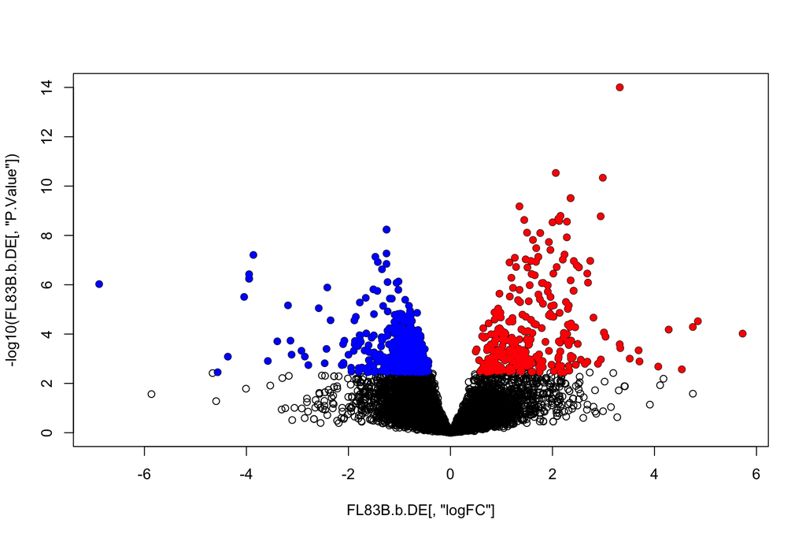

```r
points(FL83B.b.DE[sel,"logFC"], -log10(FL83B.b.DE[sel,"P.Value"]), pch=16, col="blue")
```

Counting and visualise differentially phosphorylated sites for Hepa 1-6 cells in control and insulin-simulated condition before imputation.

```r
Hepa1.6.b.DE <- topTable(fit2, coef="fHepa1.6_Ins - fHepa1.6_Control", number = Inf)
plot(Hepa1.6.b.DE[,"logFC"], -log10(Hepa1.6.b.DE[,"P.Value"]))
sel <- which(Hepa1.6.b.DE[,"adj.P.Val"] < 0.05 & Hepa1.6.b.DE[,"logFC"] > 0)
length(sel)
```

```
## [1] 1409
```

```r
points(Hepa1.6.b.DE[sel,"logFC"], -log10(Hepa1.6.b.DE[sel,"P.Value"]), pch=16, col="red")
sel <- which(Hepa1.6.b.DE[,"adj.P.Val"] < 0.05 & Hepa1.6.b.DE[,"logFC"] < 0)
length(sel)
```

```
## [1] 79
```

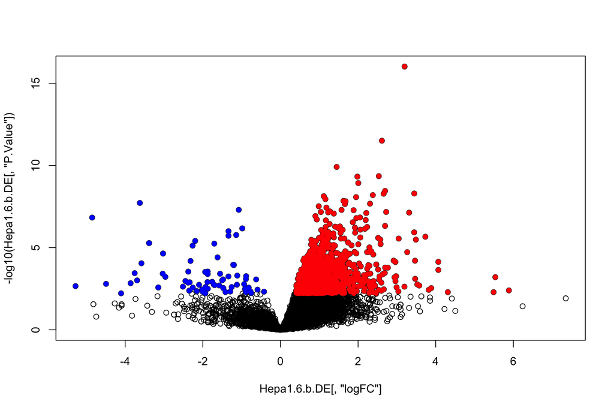

```r
points(Hepa1.6.b.DE[sel,"logFC"], -log10(Hepa1.6.b.DE[sel,"P.Value"]), pch=16, col="blue")
```

## 4.2 Analysis of data after (with) imputation

Fitting a linear model to the phosphorylation level for each phosphosite.

```r
fit <- lmFit(phospho.cells.Ins.ms, design)
contrast.matrix <- makeContrasts(fFL83B_Ins-fFL83B_Control, fHepa1.6_Ins-fHepa1.6_Control, levels=design)
fit2 <- contrasts.fit(fit, contrast.matrix)
fit2 <- eBayes(fit2)
```

Counting and visualise differentially phosphorylated sites for FL83B cells in control and insulin-simulated condition after imputation.

```r
FL83B.a.DE <- topTable(fit2, coef="fFL83B_Ins - fFL83B_Control", number = Inf)
plot(FL83B.a.DE[,"logFC"], -log10(FL83B.a.DE[,"P.Value"]))
sel <- which(FL83B.a.DE[,"adj.P.Val"] < 0.05 & FL83B.a.DE[,"logFC"] > 0)
length(sel)
```

```
## [1] 748
```

```r
points(FL83B.a.DE[sel,"logFC"], -log10(FL83B.a.DE[sel,"P.Value"]), pch=16, col="red")
sel <- which(FL83B.a.DE[,"adj.P.Val"] < 0.05 & FL83B.a.DE[,"logFC"] < 0)
length(sel)
```

```
## [1] 1218
```

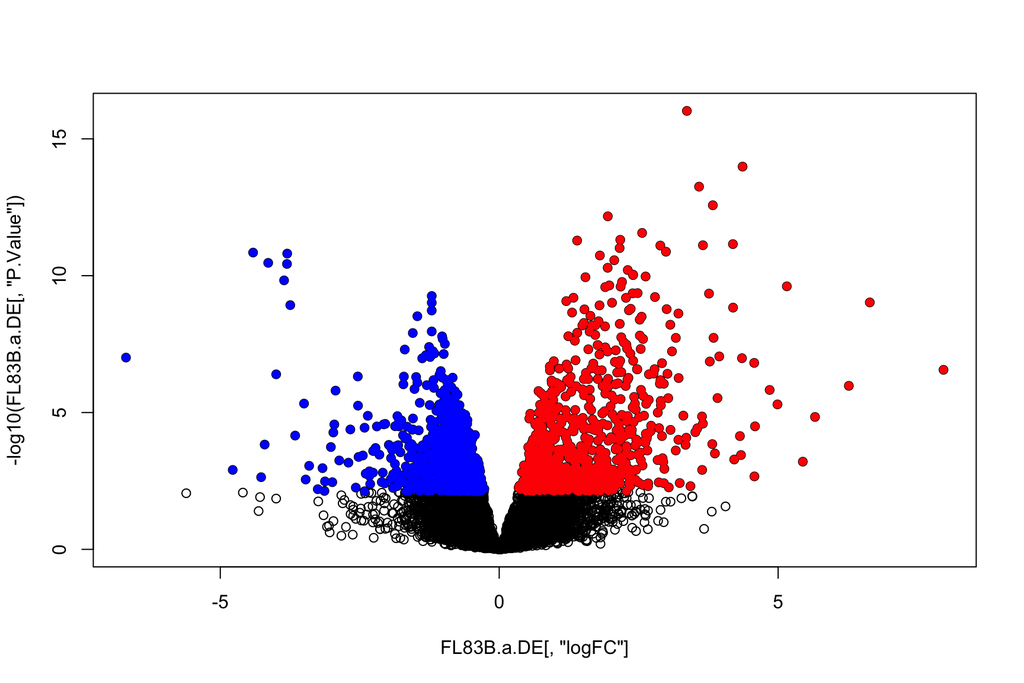

```r
points(FL83B.a.DE[sel,"logFC"], -log10(FL83B.a.DE[sel,"P.Value"]), pch=16, col="blue")
```

Counting and visualise differentially phosphorylated sites for Hepa 1-6 cells in control and insulin-simulated condition after imputation.

```r
Hepa1.6.a.DE <- topTable(fit2, coef="fHepa1.6_Ins - fHepa1.6_Control", number = Inf)
plot(Hepa1.6.a.DE[,"logFC"], -log10(Hepa1.6.a.DE[,"P.Value"]))
sel <- which(Hepa1.6.a.DE[,"adj.P.Val"] < 0.05 & Hepa1.6.a.DE[,"logFC"] > 0)
length(sel)
```

```
## [1] 578
```

```r
points(Hepa1.6.a.DE[sel,"logFC"], -log10(Hepa1.6.a.DE[sel,"P.Value"]), pch=16, col="red")
sel <- which(Hepa1.6.a.DE[,"adj.P.Val"] < 0.05 & Hepa1.6.a.DE[,"logFC"] < 0)
length(sel)
```

```
## [1] 354
```

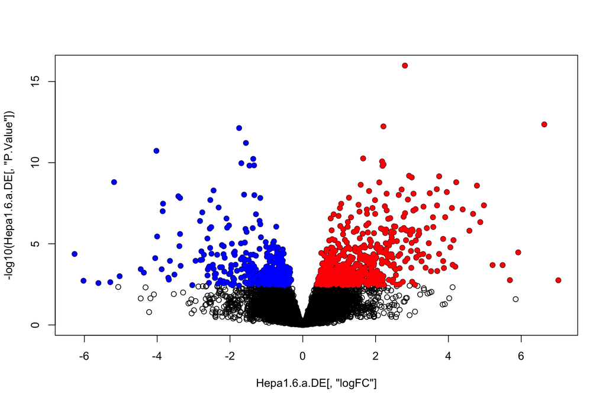

```r
points(Hepa1.6.a.DE[sel,"logFC"], -log10(Hepa1.6.a.DE[sel,"P.Value"]), pch=16, col="blue")
```

# 5 Performing signalling pathway enrichment analysis to compare data before and after imputation

## 5.1 Pathway enrichment analysis for FL83B cells in control and insulin-simulated conditions before imputation

```r
# summarise phosphosite-level information to the gene level
FL83B.b.DE.FC <- FL83B.b.DE[,"logFC"]
id <- sapply(strsplit(rownames(FL83B.b.DE), "~"), function(x)toupper(x[2]))
FL83B.b.DE.gene <- phosCollapse(FL83B.b.DE.FC, id = id, stat = abs(FL83B.b.DE.FC), by = "max")

# perform pathway enrichment analysis
FL83B.before <- pathwayRankBasedEnrichment(FL83B.b.DE.gene[,1], annotation=Pathways.reactome, alter = "greater")
```

## 5.2 Pathway enrichment analysis for FL83B cells in control and insulin-simulated conditions after imputation

```r
FL83B.a.DE.FC <- FL83B.a.DE[,"logFC"]
id <- sapply(strsplit(rownames(FL83B.a.DE), "~"), function(x)toupper(x[2]))
FL83B.a.DE.gene <- phosCollapse(FL83B.a.DE.FC, id = id, stat = abs(FL83B.a.DE.FC), by = "max")
FL83B.after <- pathwayRankBasedEnrichment(FL83B.a.DE.gene[,1], annotation=Pathways.reactome, alter = "greater")
```

## 5.3 Pathway enrichment analysis for Hepa1-6 cells in control and insulin-simulated conditions before imputation

```r
Hepa1.6.b.DE.FC <- Hepa1.6.b.DE[,"logFC"]
id <- sapply(strsplit(rownames(Hepa1.6.b.DE), "~"), function(x)toupper(x[2]))
Hepa1.6.b.DE.gene <- phosCollapse(Hepa1.6.b.DE.FC, id = id, stat = abs(Hepa1.6.b.DE.FC), by = "max")
Hepa1.6.before <- pathwayRankBasedEnrichment(Hepa1.6.b.DE.gene[,1], annotation=Pathways.reactome, alter = "greater")
```

## 5.4 Pathway enrichment analysis for Hepa1-6 cells in control and insulin-simulated conditions after imputation

```r
Hepa1.6.a.DE.FC <- Hepa1.6.a.DE[,"logFC"]
id <- sapply(strsplit(rownames(Hepa1.6.a.DE), "~"), function(x)toupper(x[2]))
Hepa1.6.a.DE.gene <- phosCollapse(Hepa1.6.a.DE.FC, id = id, stat = abs(Hepa1.6.a.DE.FC), by = "max")
Hepa1.6.after <- pathwayRankBasedEnrichment(Hepa1.6.a.DE.gene[,1], annotation=Pathways.reactome, alter = "greater")
```

## 5.5 Plot the comparison of pathway enrichment of FL83B before and after imputation.

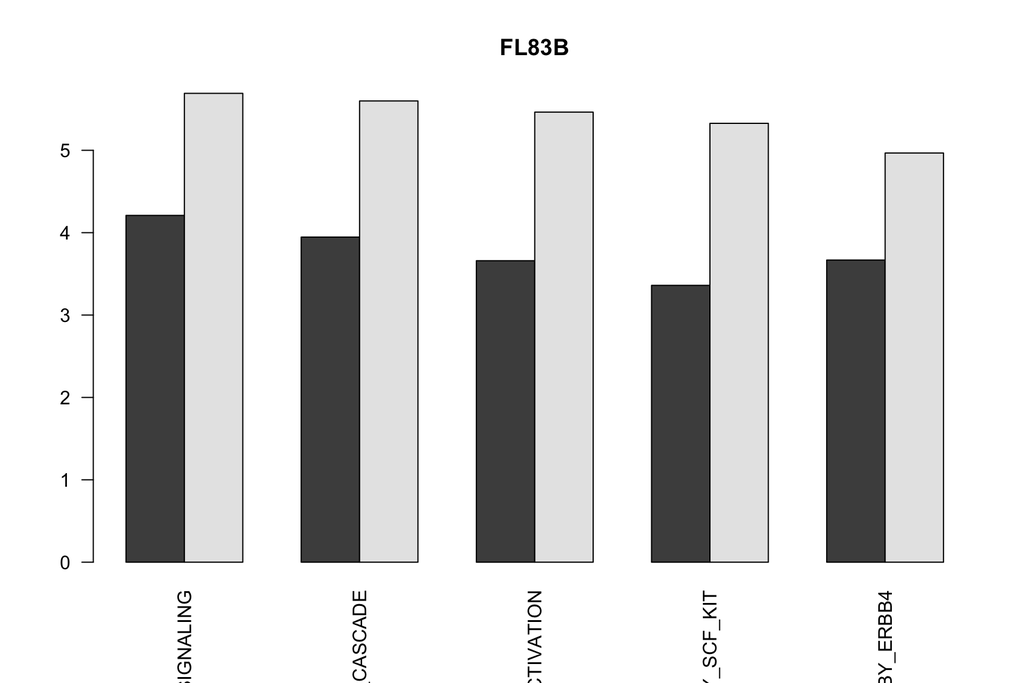

```r
sel <- intersect(rownames(FL83B.after)[1:10], rownames(FL83B.before)[1:10])[c(1, 2, 3, 4, 5)]
barplot(rbind(-log10(as.numeric(FL83B.before[sel,1])), -log10(as.numeric(FL83B.after[sel,1]))), beside = TRUE,
        names=sel, las=2, main="FL83B")
```

## 5.6 Plot the comparison of pathway enrichment of Hepa1-6 before and after imputation.

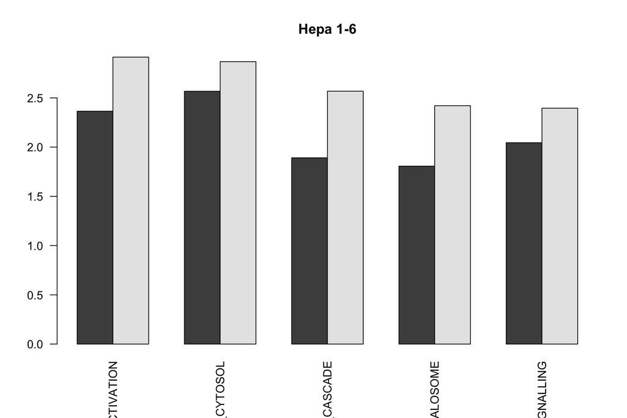

```r
sel <- intersect(rownames(Hepa1.6.after)[1:10], rownames(Hepa1.6.before)[1:10])[c(1,2,3,5,6)]
barplot(rbind(-log10(as.numeric(Hepa1.6.before[sel,1])), -log10(as.numeric(Hepa1.6.after[sel,1]))), beside = TRUE,
        names=sel, las=2, main="Hepa 1-6")
```